# NBA season calendar

```r
library(RCurl)
library(XML)
library(ggmap)
library(dplyr)
library(lubridate)
library(ggrepel)
```

### Load Necessary Functions

- **collectNBACalendar**: Function to gather from internet the NBA calendar for a specific year.
- **earth.dist**: Given latitude and longitude for two points calculate the distance between them.
- **nbaFlightsByTeam**: Returns a data frame with flights and the distance for a specific team during the season.
- **nbaRouteMap**: Plot a map with the route of a team for a calendar

```r
source('NBA season calendar Functions.R')
```

# Overview

NBA have 30 teams playing 82 games each during a regular season

Can we optmize the NBA and provide a better with lower distance travel?

# Data

### Scrapping data from Internet

Collecting the calendar from https://www.basketball-reference.com

```r
calendar<-collectNBACalendar(2016)
```

```r
head(calendar)
```

| date | time | visitor | visitor_pts | home | home_pts | season |
| --- | --- | --- | --- | --- | --- | --- |
| Fri, Jan 1, 2016 | 8:00 pm | New York Knicks | 81 | Chicago Bulls | 108 | 2016 |
| Fri, Jan 1, 2016 | 10:30 pm | Philadelphia 76ers | 84 | Los Angeles Lakers | 93 | 2016 |
| Fri, Jan 1, 2016 | 7:30 pm | Dallas Mavericks | 82 | Miami Heat | 106 | 2016 |
| Fri, Jan 1, 2016 | 7:30 pm | Charlotte Hornets | 94 | Toronto Raptors | 104 | 2016 |
| Fri, Jan 1, 2016 | 7:00 pm | Orlando Magic | 91 | Washington Wizards | 103 | 2016 |
| Sat, Jan 2, 2016 | 3:00 pm | Brooklyn Nets | 100 | Boston Celtics | 97 | 2016 |

### Transforming Date format

```r
calendar$date2<-unlist(lapply(strsplit(gsub(",","",calendar$date)," "),function(x) paste(x[2:4],collapse = "-")))
calendar$date2<-as.Date(calendar$date2,"%b-%d-%Y")
calendar<-calendar%>%
  arrange(date2)
```

```r
calendar%>%
    filter(complete.cases(.))%>%
    group_by()%>%
    summarise(min(date2),max(date2))
```

| min(date2) | max(date2) |
| --- | --- |
| 2015-10-27 | 2016-06-19 |

### Filter Regular Season Games

For this calendar there are playoffs games and we are not interested on playoffs once we are evaluating the distance traveled during the regular season.

The 2015-16 season ranged from 10-27-2015 to 04-13-2016 (https://en.wikipedia.org/wiki/2015%E2%80%9316_NBA_season)

```r
calendar<-calendar%>%
            filter(date2<='2016-04-13')
```

```r
# Quick check: Every team must have 82 games
print(sapply(unique(calendar$home),
       function(x) calendar%>%
  filter((home==x | visitor==x))%>%
  nrow()))
```

```
         Atlanta Hawks          Chicago Bulls  Golden State Warriors
                    82                     82                     82
        Boston Celtics          Brooklyn Nets        Detroit Pistons
                    82                     82                     82
       Houston Rockets     Los Angeles Lakers      Memphis Grizzlies
                    82                     82                     82
            Miami Heat        Milwaukee Bucks  Oklahoma City Thunder
                    82                     82                     82
         Orlando Magic           Phoenix Suns Portland Trail Blazers
                    82                     82                     82
      Sacramento Kings        Toronto Raptors         Indiana Pacers
                    82                     82                     82
  Los Angeles Clippers        New York Knicks    Cleveland Cavaliers
                    82                     82                     82
        Denver Nuggets     Philadelphia 76ers      San Antonio Spurs
                    82                     82                     82
  New Orleans Pelicans     Washington Wizards      Charlotte Hornets
                    82                     82                     82
Minnesota Timberwolves       Dallas Mavericks              Utah Jazz
                    82                     82                     82
```

### Define Location of Games

Based on the name of the home team we can identify the game location. For example, when the home team is 'Chicago Bulls' we know the game was hosted in Chicago.

In a simple example, for a match between 'Chicago Bulls' and 'Memphis Grizzles' where the home team is 'Chicago Bulls' we assume that there was travel from Memphis to Chicago.

```r
calendar$home_location<-unlist(lapply(strsplit(calendar$home," "),function(x) paste(x[1:(length(x)-1)],collapse=" ")))
calendar$visitor_location<-unlist(lapply(strsplit(calendar$visitor," "),function(x) paste(x[1:(length(x)-1)],collapse=" ")))
```

Even though the code above was able to identify the games location we still had to do some manual adjustments.

For example:

- Golden State -> San Franciso (The team name does not contain the city' name)
- Minnesota -> Minneapolis (The team name contains the state not the city name)

```r
calendar$home_location[calendar$home_location=="Portland Trail"]<-"Portland"
calendar$home_location[calendar$home_location=="Utah"]<-"Salt Lake City"
calendar$home_location[calendar$home_location=="Indiana"]<-"Indianapolis"
calendar$home_location[calendar$home_location=="Minnesota"]<-"Minneapolis"
calendar$home_location[calendar$home_location=="Golden State"]<-"San Francisco"
calendar$home_location[calendar$home_location=="Washington"]<-"Washington D.C."
```

### Latitude and Longitude for the Cities where the Teams are located

Using the geocode function we can download the latitude and longitude using the city name.

```r
#Example for Denver
geocode('Denver')
```

| lon | lat |
| --- | --- |
| -104.9903 | 39.73924 |

```r
# Download every latitude and longitude
cities<-unique(calendar$home_location)
pos<-geocode(cities)
citiesLocation<-data.frame(cities,pos)
```

[output not shown]

```r
head(citiesLocation)
```

| cities | lon | lat |
| --- | --- | --- |
| Atlanta | -84.38798 | 33.74900 |
| Chicago | -87.62980 | 41.87811 |
| San Francisco | -122.41942 | 37.77493 |
| Boston | -71.05888 | 42.36008 |
| Brooklyn | -73.94416 | 40.67818 |
| Detroit | -83.04575 | 42.33143 |

### Calculate the Distance between Teams based on Latitude and Longitude

Using the locations (latitude and longitude) it is possible to calculate the distance between any two cities.

```r
distance<-expand.grid(unique(calendar$home_location),unique(calendar$home_location))
names(distance)<-c("team1","team2")

distance<-merge(x=distance,
                y=citiesLocation,
                by.x="team1",
                by.y="cities",
                all.x=TRUE)
names(distance)[3:4]<-c("lon1","lat1")

distance<-merge(x=distance,
                y=citiesLocation,
                by.x="team2",
                by.y="cities",
                all.x=TRUE)
names(distance)[5:6]<-c("lon2","lat2")
```

```r
head(distance)
```

| team2 | team1 | lon1 | lat1 | lon2 | lat2 |
| --- | --- | --- | --- | --- | --- |
| Atlanta | Atlanta | -84.38798 | 33.74900 | -84.38798 | 33.749 |
| Atlanta | New York | -74.00594 | 40.71278 | -84.38798 | 33.749 |
| Atlanta | Phoenix | -112.07404 | 33.44838 | -84.38798 | 33.749 |
| Atlanta | Denver | -104.99025 | 39.73924 | -84.38798 | 33.749 |
| Atlanta | San Antonio | -98.49363 | 29.42412 | -84.38798 | 33.749 |
| Atlanta | Milwaukee | -87.90647 | 43.03890 | -84.38798 | 33.749 |

Calculate distance between two cities

```r
distance$distanceKM<-apply(distance[,names(distance)%in%c('lon1','lat1','lon2','lat2')],1,function(x) earth.dist(x[1],x[2],x[3],x[4],R=6378.145))
```

```r
head(distance)
```

| team2 | team1 | lon1 | lat1 | lon2 | lat2 | distanceKM |
| --- | --- | --- | --- | --- | --- | --- |
| Atlanta | Atlanta | -84.38798 | 33.74900 | -84.38798 | 33.749 | 0.000 |
| Atlanta | New York | -74.00594 | 40.71278 | -84.38798 | 33.749 | 1201.665 |
| Atlanta | Phoenix | -112.07404 | 33.44838 | -84.38798 | 33.749 | 2559.549 |
| Atlanta | Denver | -104.99025 | 39.73924 | -84.38798 | 33.749 | 1949.539 |
| Atlanta | San Antonio | -98.49363 | 29.42412 | -84.38798 | 33.749 | 1420.095 |
| Atlanta | Milwaukee | -87.90647 | 43.03890 | -84.38798 | 33.749 | 1078.468 |

### Function to calculate Distance traveled by a Team during the season

The nbaFlightsByTeam function returns a data frame with flights and the distance for a specific team during the season.

```r
PHI_flights<-nbaFlightsByTeam(calendar,"Philadelphia 76ers",date=TRUE)
```

```r
head(PHI_flights)
```

| flight_from | flight_to | distance |
| --- | --- | --- |
| Philadelphia | Boston | 436.1181 |
| Boston | Philadelphia | 436.1181 |
| Philadelphia | Philadelphia | 0.0000 |
| Philadelphia | Milwaukee | 1115.2003 |
| Milwaukee | Cleveland | 539.5069 |
| Cleveland | Philadelphia | 576.9254 |

### Philadelphia 76ers Travel Map

```
Warning message:
"`panel.margin` is deprecated. Please use `panel.spacing` property instead"
```

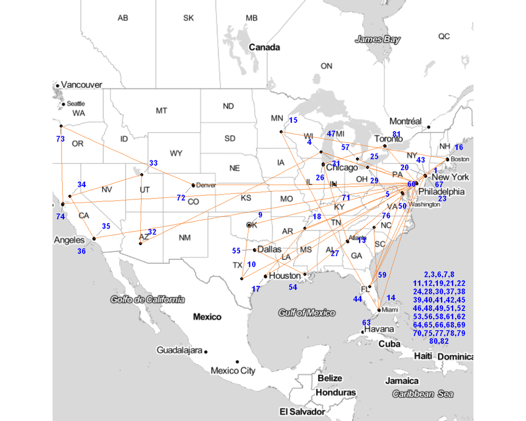

```r
options(repr.plot.width=10, repr.plot.height=8)
nbaRouteMap(calendar,"Philadelphia 76ers")
```

To get the total kilometers traveled by the Philadelphia 76ers during the 2015-16 regular season we just have to sum the variable distance.

```r
round(sum(PHI_flights$distance),2)
```

62334.61

### Total distance traveled by team during 2015-16 season

```r
teams<-unique(calendar$home)
total_distance_by_team<-sapply(teams,function(x) sum(nbaFlightsByTeam(calendar,x)$distance))
```

```r
total_distance_by_team<-as.data.frame(total_distance_by_team[order(total_distance_by_team,decreasing=TRUE)])
total_distance_by_team$team<-rownames(total_distance_by_team)
rownames(total_distance_by_team)<-NULL
colnames(total_distance_by_team)<-c('distance','team')
total_distance_by_team<-total_distance_by_team[c(2,1)]
```

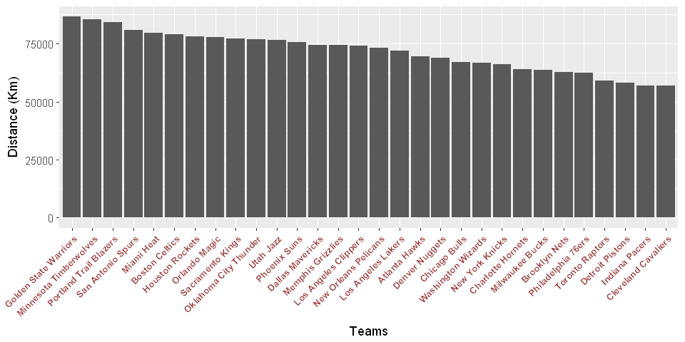

```r
options(repr.plot.width=8, repr.plot.height=4)
ggplot(total_distance_by_team,aes(x=reorder(team,-distance),distance))+
geom_bar(stat = "identity")+
labs(x="Teams")+
labs(y="Distance (Km)")+
 theme(axis.text.x = element_text(face="bold", color="#993333",
                           size=8, angle=45, hjust=1))
```

Interesting to check that both team that made NBA final are on the extrems. No, there is no correlation :P

```r
round(sum(total_distance_by_team$distance),2)
```

2149348.06

### Propose a new calendar

If we shuffle the orders of the lines from the original calendar we can create a new calendar.

```r
randomCalendar <- calendar[sample(nrow(calendar),replace=FALSE),]
```

```r
randomCalendar%>%
select(home,visitor)%>%
filter(home=="Philadelphia 76ers" | visitor=="Philadelphia 76ers")%>%
head()
```

| home | visitor |
| --- | --- |
| Philadelphia 76ers | Chicago Bulls |
| Minnesota Timberwolves | Philadelphia 76ers |
| Philadelphia 76ers | Atlanta Hawks |
| Philadelphia 76ers | Washington Wizards |
| Detroit Pistons | Philadelphia 76ers |
| Denver Nuggets | Philadelphia 76ers |

As you can see the total distance traveled by Philadelphia 76ers with this calendar has increased.

```r
cat("Original Calendar:\t",
    sum(nbaFlightsByTeam(calendar,"Philadelphia 76ers",date=FALSE)$distance),
    "\nRandom Calendar:\t",sum(nbaFlightsByTeam(randomCalendar,"Philadelphia 76ers",date=FALSE)$distance))
```

```
Original Calendar:	 62334.61
Random Calendar:	 102711.7
```

Total distance traveled also has increased.

```r
cat("Original Calendar:\t",
    sum(sapply(teams,function(x) sum(nbaFlightsByTeam(calendar,x,date=FALSE)$distance))),
        "\nCandidate Calendar:\t",
        sum(sapply(teams,function(x) sum(nbaFlightsByTeam(randomCalendar,x,date=FALSE)$distance))))
```

```
Original Calendar:	 2149348
Candidate Calendar:	 3137937
```

### Would be able to create a new calendar a with low distance traveled.

Let's create 1,000 random calendars and check the distribution of the total distance traveled.

```r
result<-rep(NA,1000)
for(i in 1:length(result)){
    c_<-calendar[sample(nrow(calendar),replace=FALSE),]
    result[i]<-sum(sapply(teams,function(x) sum(nbaFlightsByTeam(c_,x,date=FALSE)$distance)))
}
```

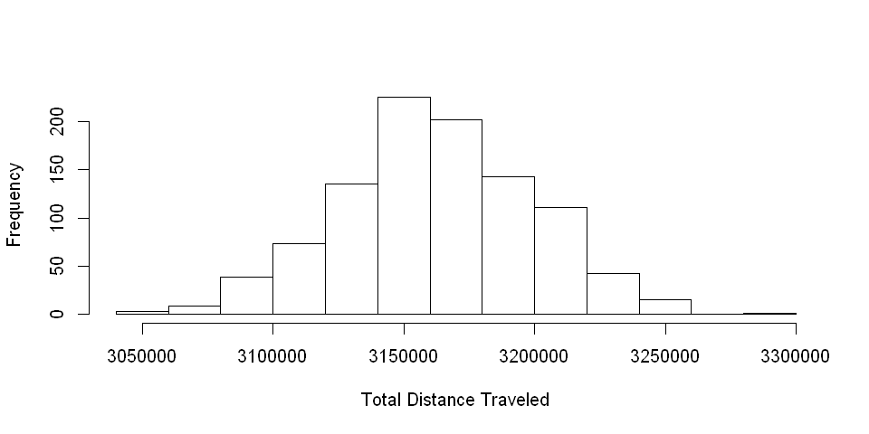

```r
hist(result,main="",xlab="Total Distance Traveled")
```

As you can see, find the calendar with a very low distance traveled is not an easy task. We randomly generated 1,000 calendar and the minimum result was not even close to the original calendar

```r
min(result)
```

3050827.35535584

Is there a way to create a calendar with as low total distanca traveled as the original?

The answer is YES... Of course, the NBA came up with this then there is an alternative.